**Mixed Beverage Gross Receipts Data**

Welcome to our project where we review a file containing a list of taxpayers who were required to tax reports regarding mixed beverage receipts. Our project analyzes data regarding Mixed Beverages receipts*, and how they compare in the respective zip codes in which they were sold. This topic is very interesting because we can analyze how data compares across zip codes with different demographics such as wealth, diversity, etc.

We created many different visualizations to help analyze the data

The first preliminary visualization shows Mean and median household incomes in Austin’s 15 most populous zip codes

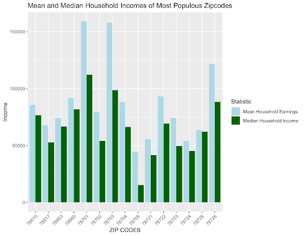

The second preliminary visualization shows Total Receipts stratified by Alcohol Type/Cover Charge in Austin’s 15 top selling zip codes

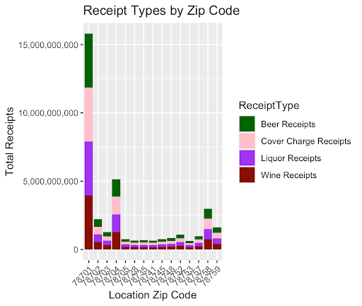

The third preliminary visualization shows Classification of Alcohol Sales By Number of Establishments in Austin’s Top Selling Zip Codes

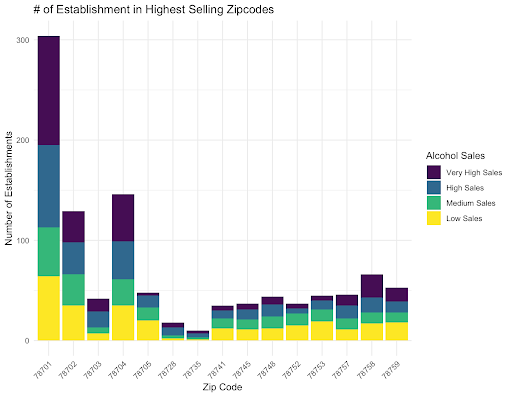

Next, we created four different hypothesis that we tested using the data.

Hypothesis 1: Higher consumer income correlates to higher ticket alcohol receipts To evaluate this hypothesis, we created this visual

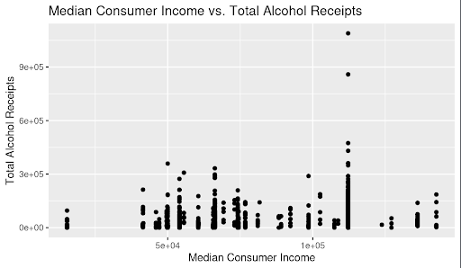

As seen in the data, The hypothesis is not supported. There is a correlation coefficient of 0.186 which shows little correlation.

Hypothesis 2: Downtown zip codes of larger cities will have the largest number of receipts To evaluate this hypothesis, we created this visual

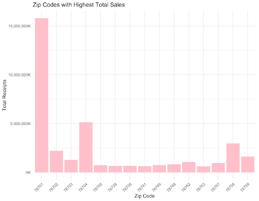

As seen in the data, Our hypothesis is correct! The highest selling zip codes are those in downtown Austin.

Hypothesis 3: A longer active alcohol license correlates with an increased number of receipts To evaluate this hypothesis, we created this visual

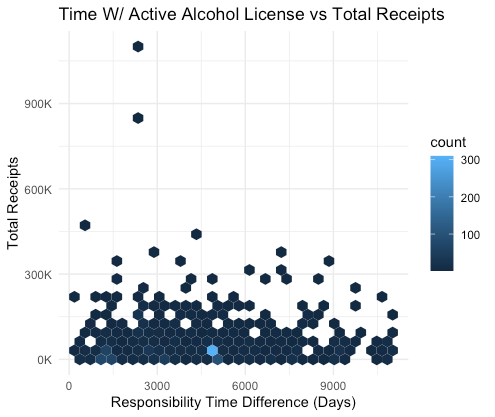

As seen in the data, our hypothesis was not supported. There is a correlation coefficient of ~0.088. This shows almost no correlation.

Hypothesis 4: Beer sales will far outweigh that of liquor and wine sales To evaluate this hypothesis, we created this visual

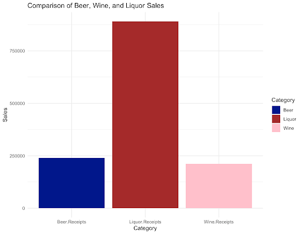

As seen in the data, our hypothesis is wrong! Total liquor sales are by far higher than total wine or beer receipts, although beer receipts are higher than wine.

Next, we created two different correlation maps to help us visualize the correlation between different variables

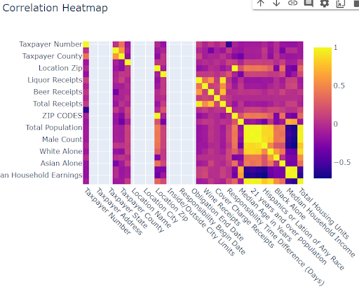

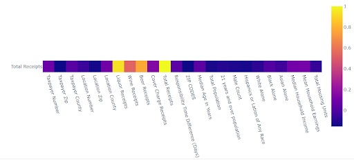

After that, we created some Decision Tree Optimization models, as well as a Random Forest Feature Importance Model

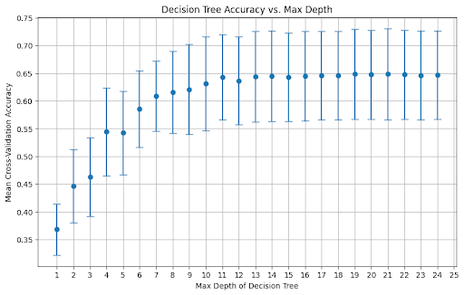

[figure not shown]

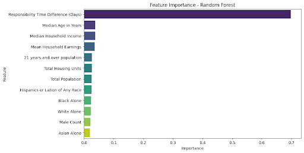